# R Notebook

```r
library(readr)
titanic <- read_delim("titanic.csv", ";",
    escape_double = FALSE, trim_ws = TRUE)
```

```r
library(tidyverse)
```

```r
library(e1071)
```

```r
library(caret)
```

```r
library(pROC)
```

```r
titanic1 <- titanic %>%
  mutate(name = str_to_lower(name)) %>%
  mutate(home.dest = str_to_lower(home.dest)) %>%
  mutate(age = as.numeric(str_replace(age,",","."))) %>%
  mutate(fare = as.numeric(str_replace(fare, ",", "."))) %>%
  mutate(survived = as.factor(survived))
```

## Bitte erstellen Sie ein Notebook mit weiteren Features.

1. Zusammenhang zwischen Geschlecht, Alter, Klasse und Überlebensrate mit SVM und 3 Variablen.

```r
titanic_akt <- titanic1 %>%
  select(survived, age, pclass, sex) %>%
  mutate(sex = ifelse(sex == "female", 1, 0))
```

Alle Variablen sind numerisch bis auf survived (factor).

```r
titanic_akt <- na.omit(titanic_akt)
```

```r
train_control <- trainControl(method = "cv", number = 10, , savePredictions = TRUE)
```

```r
set.seed(393)
inTrain <- createDataPartition(
  y = titanic_akt$survived,
  p = .8,
  list = FALSE)
training <- titanic_akt[ inTrain,]
testing  <- titanic_akt[-inTrain,]
```

```r
model_svm <- train(survived~., data = training, trControl = train_control, method = "svmLinear")

summary(model_svm)
```

```
Length  Class   Mode
     1   ksvm     S4
```

```r
pred <- predict(model_svm, testing[,-1], probability = FALSE)
```

```r
model_svm$pred
```

| pred | obs | rowIndex | C | Resample |
| --- | --- | --- | --- | --- |
| 1 | 1 | 11 | 1 | Fold01 |
| 0 | 1 | 47 | 1 | Fold01 |
| 1 | 1 | 50 | 1 | Fold01 |
| 1 | 1 | 54 | 1 | Fold01 |
| 0 | 0 | 56 | 1 | Fold01 |
| 0 | 0 | 59 | 1 | Fold01 |
| 1 | 1 | 72 | 1 | Fold01 |
| 1 | 1 | 77 | 1 | Fold01 |
| 0 | 1 | 88 | 1 | Fold01 |
| 0 | 1 | 90 | 1 | Fold01 |

[output cut: 828 more lines]

```r
(test_results <- cbind(pred, testing))
```

| pred | survived | age | pclass | sex |
| --- | --- | --- | --- | --- |
| 0 | 1 | 0.9167 | 1 | 0 |
| 1 | 1 | 18.0000 | 1 | 1 |
| 1 | 1 | 24.0000 | 1 | 1 |
| 0 | 0 | 24.0000 | 1 | 0 |
| 0 | 0 | 25.0000 | 1 | 0 |
| 0 | 0 | 42.0000 | 1 | 0 |
| 1 | 1 | 59.0000 | 1 | 1 |
| 1 | 1 | 60.0000 | 1 | 1 |
| 0 | 0 | 45.0000 | 1 | 0 |
| 1 | 1 | 58.0000 | 1 | 1 |

[output cut: 198 more lines]

```r
test_results <- test_results %>%
  mutate(survived = as.numeric(survived)) %>%
  mutate(pred = as.numeric(pred))
```

```r
table(test_results$pred, testing$survived)
```

```
      0   1
  1 110  22
  2  13  63
```

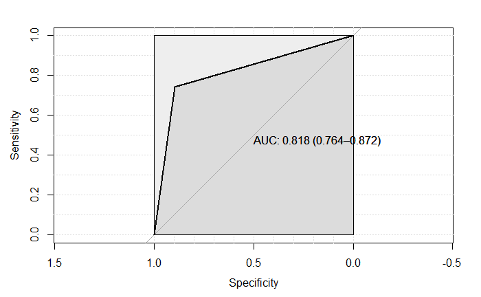

```r
pROC_obj <- roc(test_results$survived, test_results$pred,
            smoothed = TRUE,
            ci = TRUE, ci.alpha = 0.9, stratified = FALSE,
            plot = TRUE, auc.polygon = TRUE, max.auc.polygon = TRUE, grid = TRUE,
            print.auc = TRUE, show.thres = TRUE)
```

Der AUC liegt bei 0,818, was bedeutet, dass die Vorhersagbarkeit der Überlebensrate anhand der Klasse, des Alters und Geschlechts sehr gut ist.

2. Zusammenhang zwischen Preis des Tickets, Alter, Klasse, Geschlecht und Überlebensrate mit SVM und 4 Variablen.

```r
titanic_askt <- titanic1 %>%
  select(survived, age, sex, pclass, fare) %>%
  mutate(sex = ifelse(sex == "female", 1, 0))
```

```r
titanic_askt <- na.omit(titanic_askt)
```

```r
train_control <- trainControl(method = "cv", number = 10, , savePredictions = TRUE)
```

```r
set.seed(393)
inTrain <- createDataPartition(
  y = titanic_askt$survived,
  p = .8,
  list = FALSE)
training <- titanic_askt[ inTrain,]
testing  <- titanic_askt[-inTrain,]
```

```r
model_svm <- svm(formula = survived ~ ., data = training, probability = TRUE)
summary(model_svm)
```

```
Call:
svm(formula = survived ~ ., data = training, probability = TRUE)


Parameters:
   SVM-Type:  C-classification
 SVM-Kernel:  radial
       cost:  1

Number of Support Vectors:  409

 ( 204 205 )


Number of Classes:  2

Levels:
 0 1
```

```r
pred <- predict(model_svm, testing[,-1], probability = TRUE)
```

```r
(test_results <- cbind(pred, testing))
```

|  | pred | survived | age | sex | pclass | fare |
| --- | --- | --- | --- | --- | --- | --- |
| 1 | 1 | 1 | 0.9167 | 0 | 1 | 151.5500 |
| 2 | 1 | 1 | 18.0000 | 1 | 1 | 227.5250 |
| 3 | 1 | 1 | 24.0000 | 1 | 1 | 69.3000 |
| 4 | 0 | 0 | 24.0000 | 0 | 1 | 247.5208 |
| 5 | 0 | 0 | 25.0000 | 0 | 1 | 26.0000 |
| 6 | 0 | 0 | 42.0000 | 0 | 1 | 26.5500 |
| 7 | 1 | 1 | 59.0000 | 1 | 1 | 51.4792 |
| 8 | 1 | 1 | 60.0000 | 1 | 1 | 76.2917 |
| 9 | 0 | 0 | 45.0000 | 0 | 1 | 26.5500 |
| 10 | 1 | 1 | 58.0000 | 1 | 1 | 512.3292 |

[output cut: 198 more lines]

```r
test_results <- test_results %>%
  mutate(survived = as.numeric(survived)) %>%
  mutate(pred = as.numeric(pred))
```

```r
head(attr(pred, "probabilities"))
```

```
          1          0
1 0.8793168 0.12068322
2 0.8658897 0.13411028
3 0.9043755 0.09562449
4 0.3048929 0.69510706
5 0.4635091 0.53649088
6 0.2493699 0.75063014
```

```r
confusionMatrix(pred,testing$survived)
```

```
Confusion Matrix and Statistics

          Reference
Prediction   0   1
         0 116  24
         1   7  61

               Accuracy : 0.851
                 95% CI : (0.7952, 0.8964)
    No Information Rate : 0.5913
    P-Value [Acc > NIR] : 4.122e-16

                  Kappa : 0.6818

 Mcnemar's Test P-Value : 0.004057

            Sensitivity : 0.9431
            Specificity : 0.7176
         Pos Pred Value : 0.8286
         Neg Pred Value : 0.8971
             Prevalence : 0.5913
         Detection Rate : 0.5577
   Detection Prevalence : 0.6731
      Balanced Accuracy : 0.8304

       'Positive' Class : 0
```

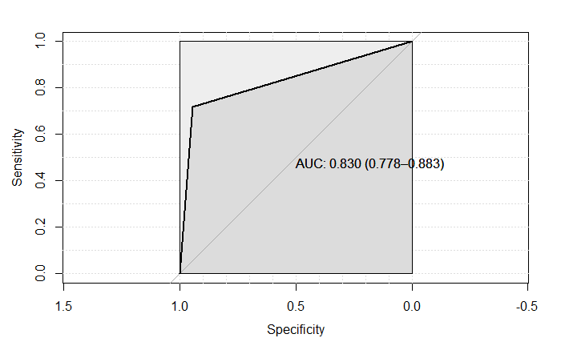

```r
pROC_obj <- roc(test_results$survived, test_results$pred,
            smoothed = TRUE,
            ci = TRUE, ci.alpha = 0.9, stratified = FALSE,
            plot = TRUE, auc.polygon = TRUE, max.auc.polygon = TRUE, grid = TRUE,
            print.auc = TRUE, show.thres = TRUE)
```

Hier erreichen wir erneut einen sehr guten AUC mit 0,830 Das bedeutet, dass die Überlebensrate sich sehr gut mit dem Alter, Geschlecht, der Klasse und dem Ticketpreis vorhersagen lässt. Da der AUC ähnlich ist wie bei der vorherigen Berechnung ohne Ticketpreis, lässt sich sagen, dass der Preis des Tickets wenig zu der Vorhersagbarkeit der Überlebensrate beiträgt.

3. Man könnte statt des Preises die Variablen sibsp und parch hinzufügen. Es könnte schließlich auch einen Einfluss auf das Überleben gehabt haben, ob Reisende allein unterwegs waren oder eben mit Eltern, Kindern, Geschwistern oder Partner*innen.

```r
titanic_all <- titanic1 %>%
  select(survived, age, sex, pclass, sibsp, parch) %>%
  mutate(sex = ifelse(sex == "female", 1, 0))
```

```r
titanic_all <- na.omit(titanic_all)
```

```r
train_control <- trainControl(method = "cv", number = 10, , savePredictions = TRUE)
```

```r
set.seed(393)
inTrain <- createDataPartition(
  y = titanic_all$survived,
  p = .8,
  list = FALSE)
training <- titanic_all[ inTrain,]
testing  <- titanic_all[-inTrain,]
```

```r
model_svm <- svm(formula = survived ~ ., data = training, probability = TRUE)
summary(model_svm)
```

```
Call:
svm(formula = survived ~ ., data = training, probability = TRUE)


Parameters:
   SVM-Type:  C-classification
 SVM-Kernel:  radial
       cost:  1

Number of Support Vectors:  410

 ( 201 209 )


Number of Classes:  2

Levels:
 0 1
```

```r
pred <- predict(model_svm, testing[,-1], probability = TRUE)
```

```r
(test_results <- cbind(pred, testing))
```

|  | pred | survived | age | sex | pclass | sibsp | parch |
| --- | --- | --- | --- | --- | --- | --- | --- |
| 1 | 1 | 1 | 0.9167 | 0 | 1 | 1 | 2 |
| 2 | 1 | 1 | 18.0000 | 1 | 1 | 1 | 0 |
| 3 | 1 | 1 | 24.0000 | 1 | 1 | 0 | 0 |
| 4 | 1 | 0 | 24.0000 | 0 | 1 | 0 | 1 |
| 5 | 0 | 0 | 25.0000 | 0 | 1 | 0 | 0 |
| 6 | 0 | 0 | 42.0000 | 0 | 1 | 0 | 0 |
| 7 | 1 | 1 | 59.0000 | 1 | 1 | 2 | 0 |
| 8 | 1 | 1 | 60.0000 | 1 | 1 | 0 | 0 |
| 9 | 0 | 0 | 45.0000 | 0 | 1 | 0 | 0 |
| 10 | 1 | 1 | 58.0000 | 1 | 1 | 0 | 1 |

[output cut: 198 more lines]

```r
test_results <- test_results %>%
  mutate(survived = as.numeric(survived)) %>%
  mutate(pred = as.numeric(pred))
```

```r
head(attr(pred, "probabilities"))
```

```
          1         0
1 0.8958830 0.1041170
2 0.8638681 0.1361319
3 0.8396793 0.1603207
4 0.5039678 0.4960322
5 0.2406942 0.7593058
6 0.2010984 0.7989016
```

```r
confusionMatrix(pred,testing$survived)
```

```
Confusion Matrix and Statistics

          Reference
Prediction   0   1
         0 116  23
         1   7  62

               Accuracy : 0.8558
                 95% CI : (0.8005, 0.9005)
    No Information Rate : 0.5913
    P-Value [Acc > NIR] : < 2e-16

                  Kappa : 0.6926

 Mcnemar's Test P-Value : 0.00617

            Sensitivity : 0.9431
            Specificity : 0.7294
         Pos Pred Value : 0.8345
         Neg Pred Value : 0.8986
             Prevalence : 0.5913
         Detection Rate : 0.5577
   Detection Prevalence : 0.6683
      Balanced Accuracy : 0.8363

       'Positive' Class : 0
```

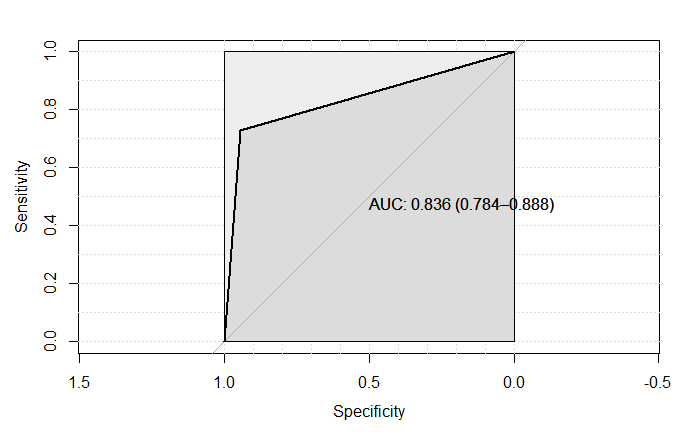

```r
pROC_obj <- roc(test_results$survived, test_results$pred,
            smoothed = TRUE,
            ci = TRUE, ci.alpha = 0.9, stratified = FALSE,
            plot = TRUE, auc.polygon = TRUE, max.auc.polygon = TRUE, grid = TRUE,
            print.auc = TRUE, show.thres = TRUE)
```

Mit einem AUC von 0,836 haben wir eine sehr gute Vorhersagbarkeit der Überlebensrate herstellen können.

## Was sind die Unterschiede in der Performance der Algorithmen?

Um uns die Unterschiede in der Performance der Algorithmen anzuschauen, setzen wir die gleiche Kombination aus Features mit den unterschiedlichen Algorithmen um. Ich verwende hierfür die Variablen Geschlecht, Alter, Klasse, Geschwister oder Partner*innen (sibsp) und Eltern oder Kinder (parch), wie in Beispiel 3 in Aufgabe eins mit SVM umgesetzt. Der dabei erzielte AUC lag bei 0,836..

### 2. Naive Bayes

```r
my_training <- training %>%
  mutate(sex = as.factor(sex))%>%
  mutate(pclass = as.factor(pclass)) %>%
  mutate(age = as.factor(ifelse(age < 14, "child", "adult"))) %>%
  mutate(sibsp = as.factor(sibsp)) %>%
  mutate(parch = as.factor(parch))
```

```r
model <- naiveBayes(survived ~ ., data = my_training)
model
```

```
Naive Bayes Classifier for Discrete Predictors

Call:
naiveBayes.default(x = X, y = Y, laplace = laplace)

A-priori probabilities:
Y
        0         1
0.5918854 0.4081146

Conditional probabilities:
   age
Y       adult     child
  0 0.9233871 0.0766129
  1 0.8801170 0.1198830

   sex
Y           0         1
  0 0.8326613 0.1673387
  1 0.3304094 0.6695906

   pclass
Y           1         2         3
  0 0.1471774 0.2358871 0.6169355
  1 0.4444444 0.2368421 0.3187135

   sibsp
Y             0           1           2           3           4           5           8
  0 0.679435484 0.221774194 0.030241935 0.018145161 0.036290323 0.012096774 0.002016129
  1 0.590643275 0.342105263 0.043859649 0.017543860 0.005847953 0.000000000 0.000000000

   parch
Y             0           1           2           3           4           5           6
  0 0.792338710 0.106854839 0.074596774 0.006048387 0.008064516 0.008064516 0.004032258
  1 0.643274854 0.225146199 0.111111111 0.014619883 0.002923977 0.002923977 0.000000000
```

```r
my_testing <- testing %>%
  mutate(sex = as.factor(sex)) %>%
  mutate(pclass = as.factor(pclass))%>%
  mutate(age = as.factor(ifelse(age < 14, "child", "adult"))) %>%
  mutate(sibsp = as.factor(sibsp)) %>%
  mutate(parch = as.factor(parch))

pred <- predict(model, my_testing)
table(pred, my_testing$survived)
```

```
pred   0   1
   0 109  24
   1  14  61
```

```r
(test_results <- cbind(pred, my_testing))
```

| pred | survived | age | sex | pclass | sibsp | parch |
| --- | --- | --- | --- | --- | --- | --- |
| 1 | 1 | child | 0 | 1 | 1 | 2 |
| 1 | 1 | adult | 1 | 1 | 1 | 0 |
| 1 | 1 | adult | 1 | 1 | 0 | 0 |
| 1 | 0 | adult | 0 | 1 | 0 | 1 |
| 0 | 0 | adult | 0 | 1 | 0 | 0 |
| 0 | 0 | adult | 0 | 1 | 0 | 0 |
| 1 | 1 | adult | 1 | 1 | 2 | 0 |
| 1 | 1 | adult | 1 | 1 | 0 | 0 |
| 0 | 0 | adult | 0 | 1 | 0 | 0 |
| 1 | 1 | adult | 1 | 1 | 0 | 1 |

[output cut: 198 more lines]

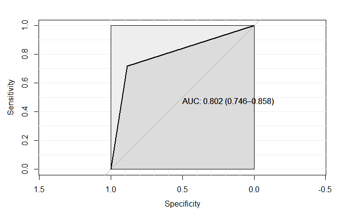

```r
test_results <- test_results %>%
  mutate(pred = as.numeric(pred))
pROC_obj <- roc(as.numeric(as.factor(test_results$survived)), test_results$pred,
            smoothed = TRUE,
            ci = TRUE, ci.alpha=0.9, stratified = FALSE,
            plot = TRUE, auc.polygon = TRUE, max.auc.polygon = TRUE, grid = TRUE,
            print.auc = TRUE, show.thres = TRUE)
```

Der AUC sieht bei Naive Bayes mit 0,802 ganz gut aus, hat aber eine leicht schlechtere Performance als mit SVM.

### 3. Decision Tree

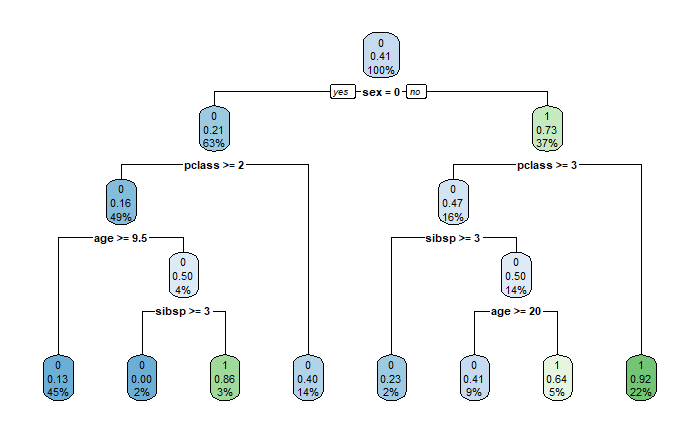

```r
library(rpart)
library(rpart.plot)
tree<- rpart(survived~., data = training, method = 'class')
rpart.plot(tree)
```

```r
dt_results <- predict(tree, testing[,-1], type = 'prob')
head(model_results_dt <- cbind(testing,dt_results),500)
```

|  | survived | age | sex | pclass | sibsp | parch | 0 | 1 |
| --- | --- | --- | --- | --- | --- | --- | --- | --- |
| 1 | 1 | 0.9167 | 0 | 1 | 1 | 2 | 0.59649123 | 0.4035088 |
| 2 | 1 | 18.0000 | 1 | 1 | 1 | 0 | 0.07692308 | 0.9230769 |
| 3 | 1 | 24.0000 | 1 | 1 | 0 | 0 | 0.07692308 | 0.9230769 |
| 4 | 0 | 24.0000 | 0 | 1 | 0 | 1 | 0.59649123 | 0.4035088 |
| 5 | 0 | 25.0000 | 0 | 1 | 0 | 0 | 0.59649123 | 0.4035088 |
| 6 | 0 | 42.0000 | 0 | 1 | 0 | 0 | 0.59649123 | 0.4035088 |
| 7 | 1 | 59.0000 | 1 | 1 | 2 | 0 | 0.07692308 | 0.9230769 |
| 8 | 1 | 60.0000 | 1 | 1 | 0 | 0 | 0.07692308 | 0.9230769 |
| 9 | 0 | 45.0000 | 0 | 1 | 0 | 0 | 0.59649123 | 0.4035088 |
| 10 | 1 | 58.0000 | 1 | 1 | 0 | 1 | 0.07692308 | 0.9230769 |

[output cut: 198 more lines]

```r
test_results2 <- test_results %>%
  mutate(pred = ifelse(pred >= 0.5, 1, 0))
table(test_results2$pred, testing$survived)
```

```
      0   1
  1 123  85
```

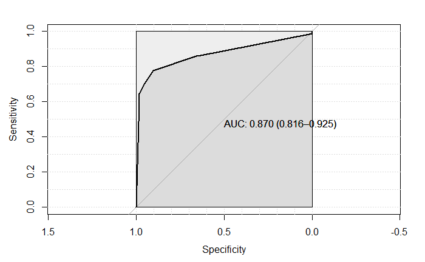

```r
pROC_obj <- roc(model_results_dt$survived,model.results.dt$`1`,
            smoothed = TRUE,
            # arguments for ci
            ci = TRUE, ci.alpha=0.9, stratified = FALSE,
            # arguments for plot
            plot = TRUE, auc.polygon = TRUE, max.auc.polygon = TRUE, grid = TRUE,
            print.auc = TRUE, show.thres = TRUE)
```

Der Decision Tree hat bei diesem Beispiel mit einem AUC von 0,870 eine bessere Performance als die anderen Algorithmen, was ungewöhnlich ist.

## Finden Sie Erklärungen dafür.

Naive Bayes schneidet in diesem Beispiel ein bisschen schlechter aus als SVM. Da bei Naive Bayes Distanzen keine Rolle spielen, kann seine Performance dadurch beeinträchtigt werden, wenn Werte wie das Alter oder der Ticketpreis mit reingenommen werden. Hier müsste man dann selbst entscheiden, ab wann ein Ticket z.B. teuer, mittel oder günstig ist und dafür verschiedene Factors erstellen. Bei solchen Berechnungen eignet sich Naive Bayes vermutlich nicht so gut, weil die Einordnung recht subjektiv sein kann. Umgekehrt eignet er sich besser als SVM, wenn mit geringen Datenmengen, die sich leicht in Kategorien einteilen lassen, gearbeitet wird. Bei dem Decision Tree lässt sich die bessere Performance entweder damit erklären, dass bei den anderen Algorithmen noch nichts optimiert wurde. Es kann auch sein, dass der Decision Tree gerade bei diesem Datensatz sehr gut funktioniert, aber nicht für andere Datenmengen geeignet ist, also eine geringe Generalität besitzt, da er sich zu gut an die vorhandenen Daten angepasst hat (Overfitting) und keine allgemeingültigen Aussagen treffen kann.